# CSCI0100 HW 3

Preston Schwartz

10/5/2016

## Hypothesis 1

```r
friends_vs_happiness <- select(responses, Number.of.friends, Happiness.in.life) %>%arrange(desc(Number.of.friends))
head(friends_vs_happiness)
```

```
##   Number.of.friends Happiness.in.life
## 1                 5                 5
## 2                 5                 5
## 3                 5                 4
## 4                 5                 4
## 5                 5                 4
## 6                 5                 2
```

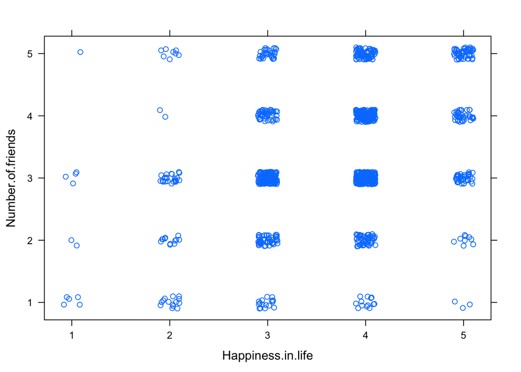

```r
#mplot(friends_vs_happiness)
xyplot( Number.of.friends ~ Happiness.in.life, data = friends_vs_happiness, main="", jitter.x=TRUE, jitter.y=TRUE)
```

There seems to be a positive relationship – the more friends one has, the happier in life they are.

## Hypothesis 2

```r
gender_vs_happiness <- select(responses, Gender, Happiness.in.life)%>%na.omit(gender_vs_happiness)
head(gender_vs_happiness)
```

```
##   Gender Happiness.in.life
## 1 female                 4
## 2 female                 4
## 3 female                 4
## 4 female                 2
## 5 female                 3
## 6   male                 3
```

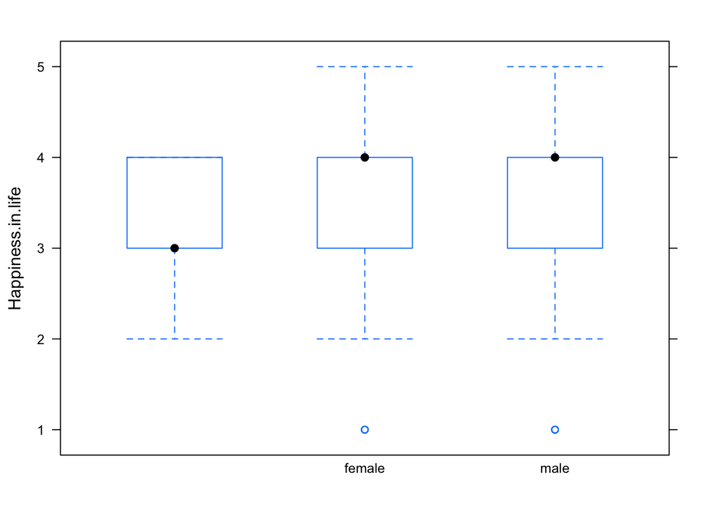

```r
#mplot(gender_vs_happiness)
bwplot( Happiness.in.life ~ Gender, data = gender_vs_happiness, main="")
```

Females and males appear to be equally happy in life, with a majority of indivudals reporting between a 3 or 4 for happiness. There are some outliers who report a happiness of 1, though.

## Hypothesis 3

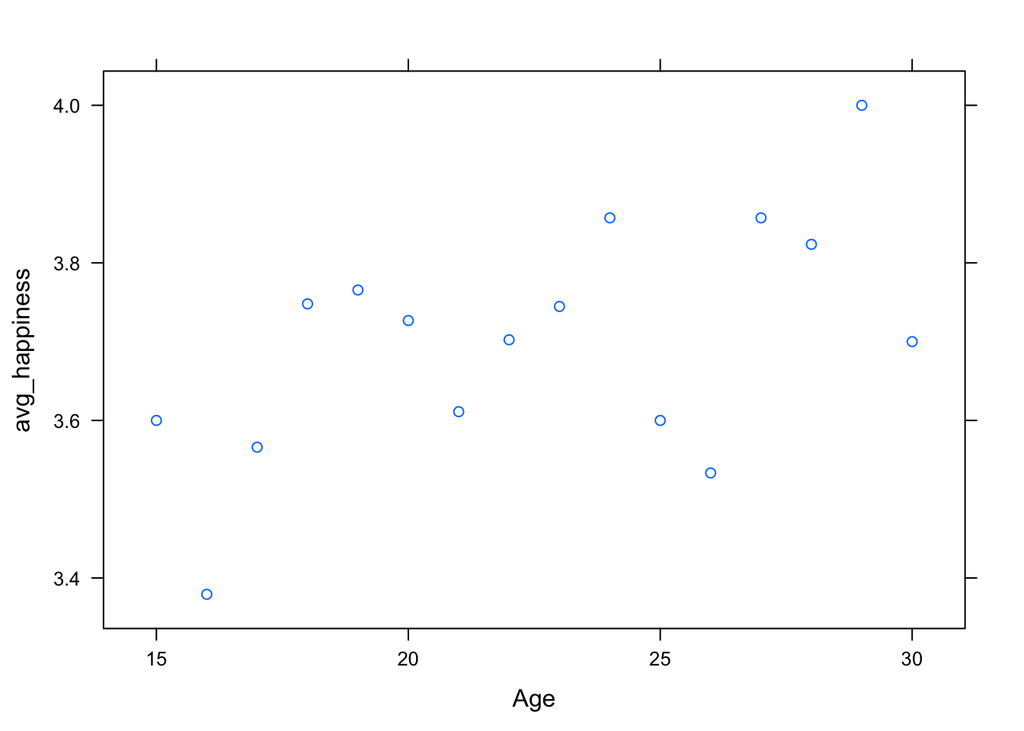

```r
happiness_vs_age <- select(responses, Age, Happiness.in.life)%>%na.omit(happiness_vs_age)%>%group_by(Age)%>%summarise(avg_happiness = mean(Happiness.in.life))
#mplot(happiness_vs_age)
xyplot( avg_happiness ~ Age, data = happiness_vs_age, main="")
```

## Hypothesis 4

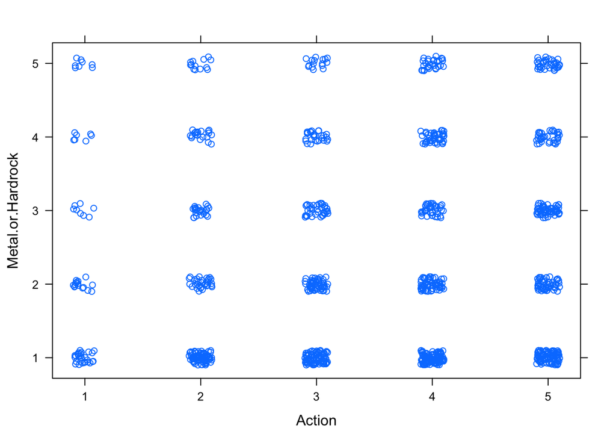

```r
heavymetal_vs_action <- select(responses, Metal.or.Hardrock, Action)%>%na.omit(heavymetal_vs_action)
#mplot(heavymetal_vs_action)
xyplot( Metal.or.Hardrock ~ Action, data = heavymetal_vs_action, main="", jitter.x=TRUE, jitter.y=TRUE)
```

It appears that there is some correlation between preferences of metal and hardrock and action movies. It can be said that a majority of those who do not like action do not like metal or hardrock. Those who like action are more likely to like metal or hardrock.

## Hypothesis 5

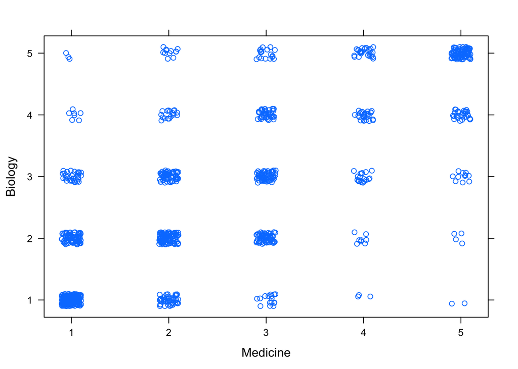

```r
biology_vs_medicine <- select(responses, Biology, Medicine)%>%na.omit(biology_vs_medicine)
#mplot(biology_vs_medicine)
xyplot( Biology ~ Medicine, data = biology_vs_medicine, main="", jitter.x=TRUE, jitter.y=TRUE)
```

There is a strong, positive relationship between biology preference and medicine preference as a career.

## Hypothesis 6

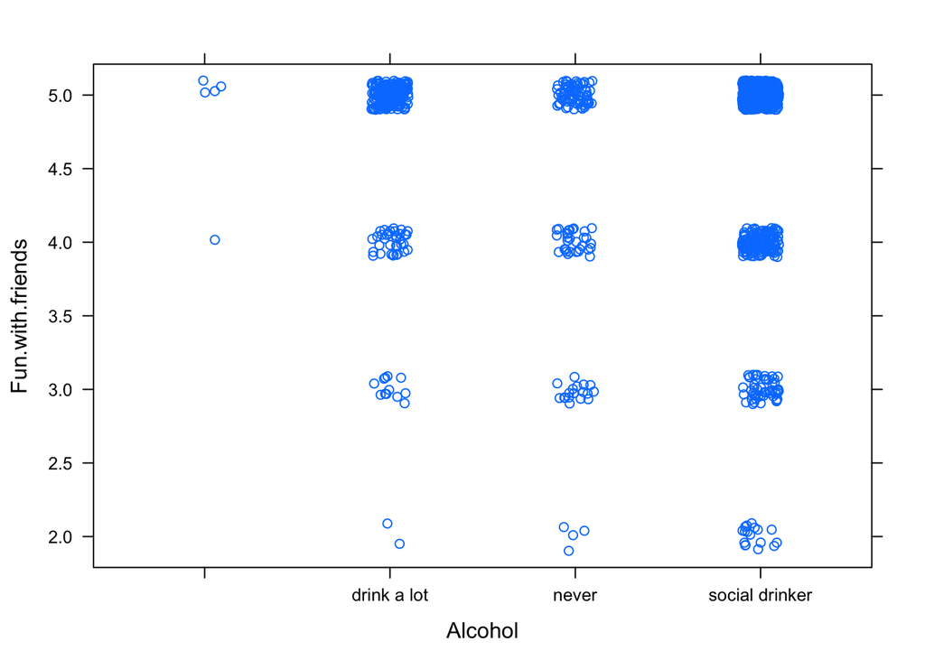

```r
fun.with.friends_vs_alcohol <- select(responses, Fun.with.friends, Alcohol)%>%group_by(Alcohol)%>%na.omit(fun.with.friends_vs_alcohol)
#mplot(fun.with.friends_vs_alcohol)
xyplot( Fun.with.friends ~ Alcohol, data = fun.with.friends_vs_alcohol, main="", jitter.x=TRUE, jitter.y=TRUE)
```

People who drink, on average, have more fun with friends. Those with a social drinker status have the most fun, followed by those who drink a lot, then by those who never drink.

## Hypothesis 7

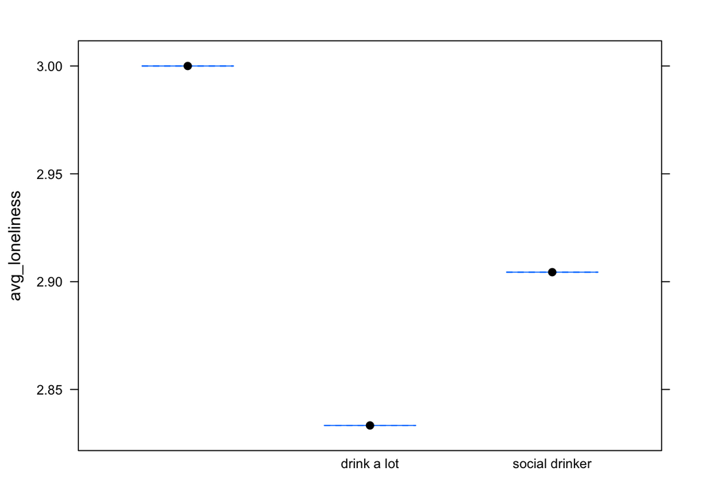

```r
loneliness_vs_alcohol <- select(responses, Loneliness, Alcohol)%>%group_by(Alcohol)%>%summarise(avg_loneliness = mean(Loneliness))%>%na.omit(loneliness_vs_alcohol)
#mplot(loneliness_vs_alcohol)
bwplot( avg_loneliness ~ Alcohol, data = loneliness_vs_alcohol, main="")
```

## Hypothesis 8

```r
romantic_vs_empathy <- select(responses, Romantic, Empathy)%>%na.omit(romantic_vs_empathy)%>%arrange(desc(Empathy))
head(romantic_vs_empathy)
```

```
##   Romantic Empathy
## 1        2       5
## 2        4       5
## 3        3       5
## 4        3       5
## 5        3       5
## 6        4       5
```

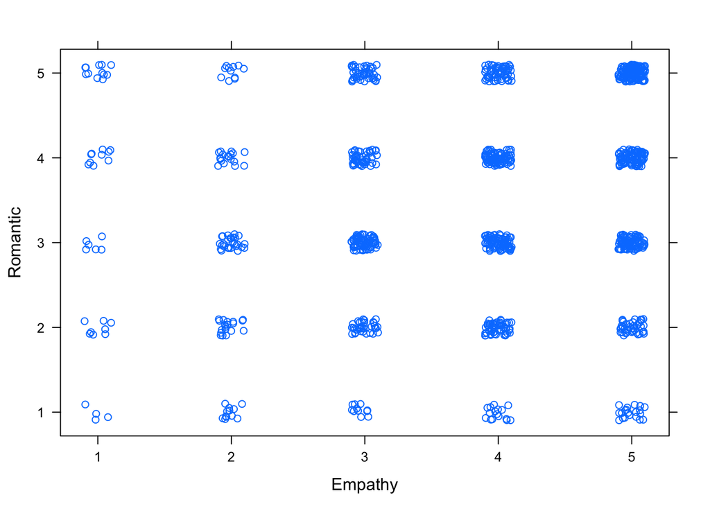

```r
#mplot(romantic_vs_empathy)
xyplot( Romantic ~ Empathy, data = romantic_vs_empathy, main="", jitter.x=TRUE, jitter.y=TRUE)
```

The individuals who report high levels of empathy most enjoy romantic themes. Those who report little to no empathy least enjoy romantic themes. Thus there is a positive relationship between one’s reported empathy and affinity for romance films.